# Отчёт по лабораторной работе №11

Операционные системы

Румянцев А. О.

Российский университет дружбы народов, Москва, Россия

20.04.2024

# Цель работы

Познакомиться с операционной системой Linux. Получить практические навыки рабо- ты с редактором Emacs.

# Задание

1. Ознакомиться с теоретическим материалом
2. Ознакомиться с редактором emacs.
3. Выполнить упражнения.
4. Ответить на контрольные вопросы.

# Теоретическое введение

Emacs — один из наиболее мощных и широко распространённых редакторов, используемых в мире UNIX. По популярности он соперничает с редактором vi и его клонами. В зависимости от ситуации, Emacs может быть:

- текстовым редактором;
- программой для чтения почты и новостей Usenet;
- интегрированной средой разработки (IDE);
- операционной системой;

Всё это разнообразие достигается благодаря архитектуре Emacs, которая позволяет расширять возможности редактора при помощи языка Emacs Lisp. На языке C написаны лишь самые базовые и низкоуровневые части Emacs, включая полнофункциональный интерпретатор языка Lisp. Таким образом, Emacs имеет встроенный язык программирования, который может использоваться для настройки, расширения и изменения поведения редактора. В действительности, большая часть того редактора, с которым пользователи Emacs работают в наши дни, написана на языке Lisp.

Первая версия редактора Emacs была написана в 70-х годах 20-го столетия Richard Stallman (Ричардом Столманом) как набор макросов для редактора TECO . В дальнейшем, уже будучи основателем Фонда Свободного программного обеспечения Free Software Foundation и проекта GNU, Stallman разработал GNU Emacs в развитие оригинального Emacs и до сих пор сопровождает эту программу. Emacs является одним из старейших редакторов. Он использовался тысячами программистов на протяжении последних 20 с лишним лет, для него создано много дополнительных пакетов расширений. Эти дополнения позволяют делать с помощью Emacs такие вещи, которые Stallman , вероятно, даже не считал возможными в начале своей работы над редактором.

# Выполнение лабораторной работы

## Открываю Emacs через терминал.

[figure not shown]

## Создаю файл lab07.sh

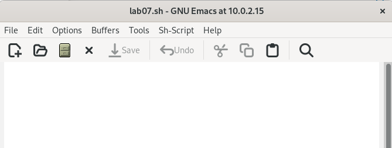

## Прописываю в файле текст программы.

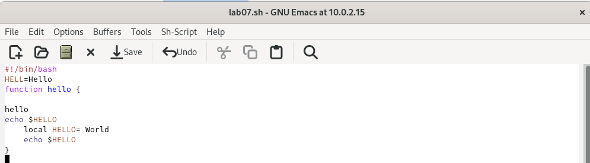

## Сохраняю файл с помощью комбинации С-x С-s.

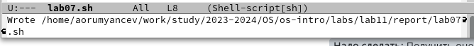

## Вырезаю одной командой целую строку (С-к)

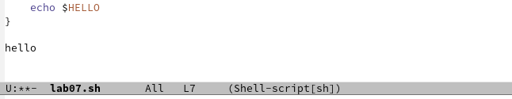

## Вставляю эту строку в конец файла (С-у).

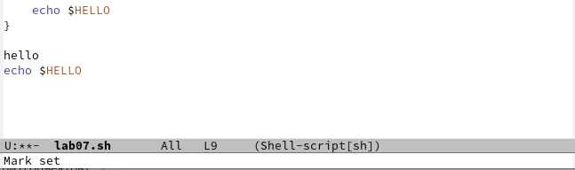

## Выделяю область текста(С-space), копирую область в буфер обмена (М-w), вырезаю эту область с помощью С-w.

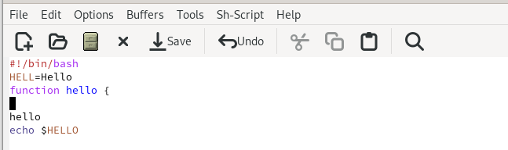

## Вставляю область в конец файла (С-у).

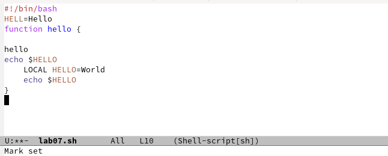

## Отменяю последнее действие С-/

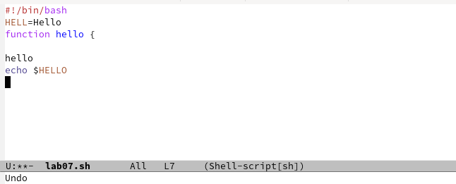

## Перевожу курсор в начало строки С-а

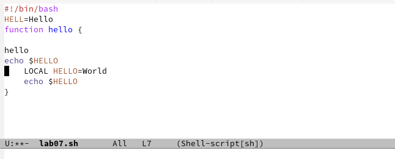

## Перемещаю курсор в конец строки С-е

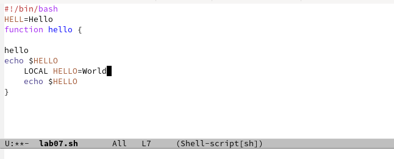

## Перемещаю курсор в начало файла М-<

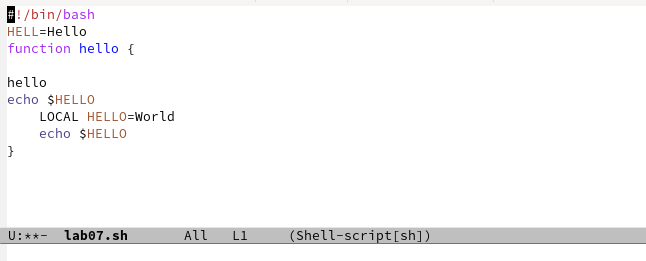

## Перемещаю курсор в конец файла М->

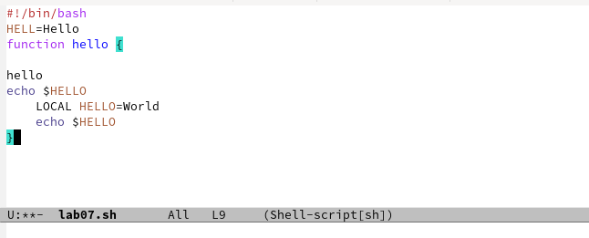

## Открываю список активных буферов в другой окне С-х С-b

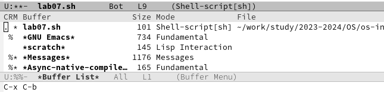

## Переключаюсь на другой буфер С-х о

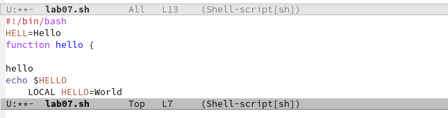

## Закрываю окно другого буфера С-х 0

[figure not shown]

## Открываю другой буфер без вывода их списка на экран с помощью С-х b

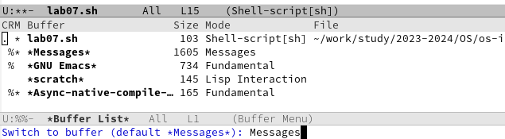

## Делю фрейм на 4 части: сначала на два окна по вертикали(С-х 3), а затем каждое из этих окон на две части по горизонтали(С-х 2).

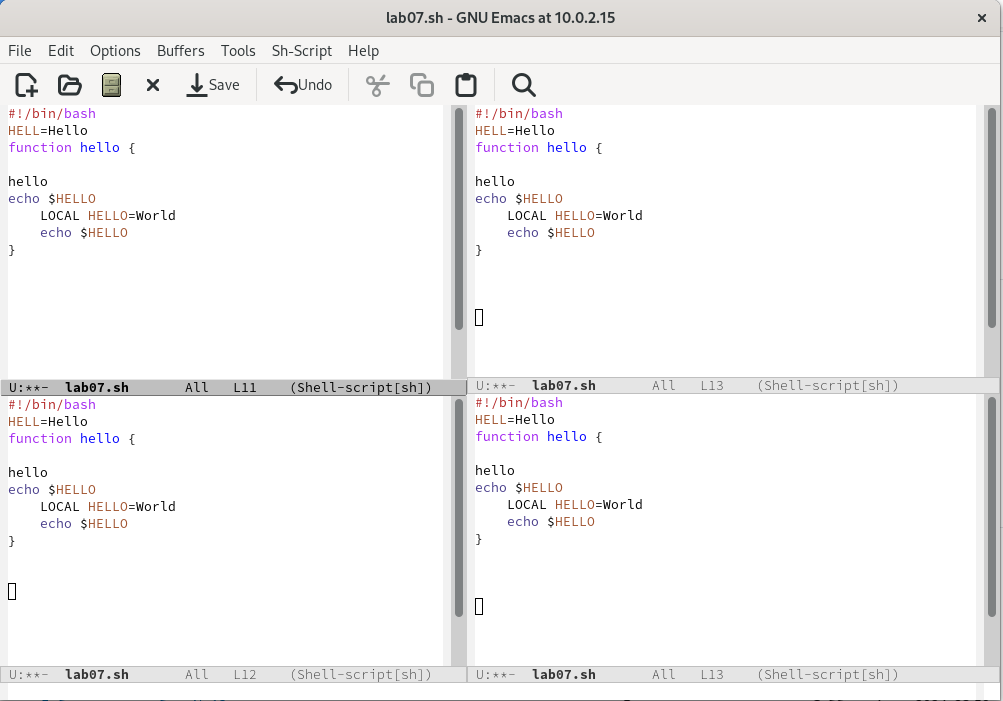

## В каждой из четырех созданных окон с помощью С-х b открыл разные буферы.

[figure not shown]

## Перехожу в режим поиска с помощью С-s, ищу слова в тексте, они подсвечиваются.

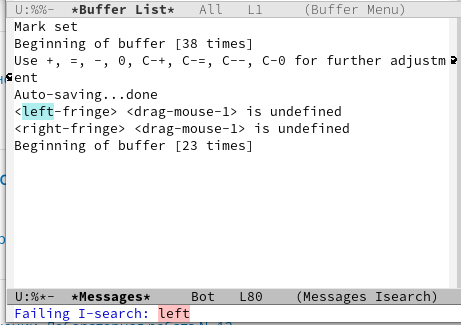

## С помощью той же комбинации С-s я могу перемещаться по результатам поиска.

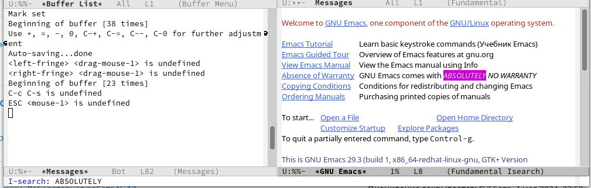

## С помощью С-g выхожу из режима поиска, снимается выделение.

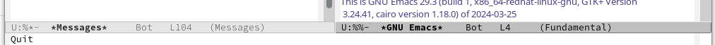

## Перехожу в режим поиска и замены с помощью М-%,ввожу какое слов хочу заменить,затем ввожу на какое хочу заменить

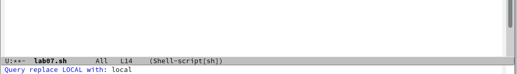

## Видим, что слова были заменены успешно

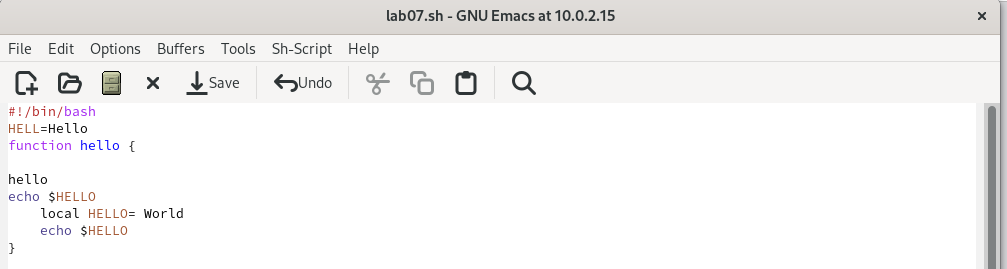

## С помощью М-s о перехожу в другой режим поиска. Он отличается от предыдущего тем, что выводит результат в отдельном окне от окна буфера.

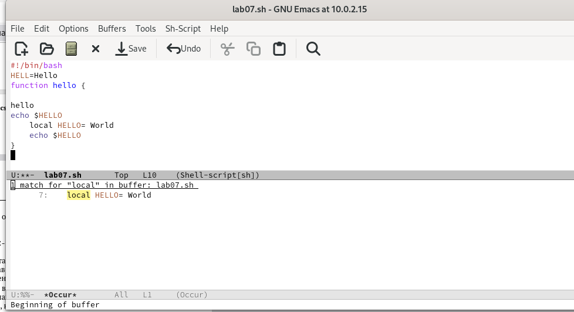

# Выводы

В ходе данной лабораторной работы я познакомился с ос Linux, получил практические навыки работы с редактором Emacs.

# Ответы на контрольные вопросы

## 1. Кратко охарактеризуйте редактор emacs.

Emacs — один из наиболее мощных и широко распространённых редакторов, используемых в мире UNIX. Написан на языке высокого уровня Lisp.

## 2. Какие особенности данного редактора могут сделать его сложным для освоения новичком?

Большое разнообразие сложных комбинаций клавиш, которые необходимы для редактирования файла и в принципе для работа с Emacs.

## 3. Своими словами опишите, что такое буфер и окно в терминологии emacs’а.

Буфер - это объект в виде текста. Окно - это прямоугольная область, в которой отображен буфер.

## 4. Можно ли открыть больше 10 буферов в одном окне?

Да, можно.

## 5. Какие буферы создаются по умолчанию при запуске emacs?

Emacs использует буферы с именами, начинающимися с пробела, для внутренних целей. Отчасти он обращается с буферами с такими именами особенным образом — например, по умолчанию в них не записывается информация для отмены изменений.

## 6. Какие клавиши вы нажмёте, чтобы ввести следующую комбинацию C-c | и C-c C-|?

Ctrl + c, а потом | и Ctrl + c Ctrl + |

## 7. Как поделить текущее окно на две части?

С помощью команды Ctrl + x 3 (по вертикали) и Ctrl + x 2 (по горизонтали).

## 8. В каком файле хранятся настройки редактора emacs?

Настройки emacs хранятся в файле . emacs, который хранится в домашней дирректории пользователя. Кроме этого файла есть ещё папка . emacs.

## 9. Какую функцию выполняет клавиша и можно ли её переназначить?

Выполняет функцию стереть, думаю можно переназначить.

## 10. Какой редактор вам показался удобнее в работе vi или emacs? Поясните почему.

Для меня удобнее был редактор Emacs, так как у него есть командая оболочка. А vi открывается в терминале, и выглядит своеобразно.